# **How to Catch a Scammer**

[figure not shown]

## Goals

[figure not shown]

- Can I identify a potential scammer based off of their Reddit profile and comment history?
- Find out if scammers use distinctive language compared to non-scammers
- Build an app to predict a user's probability of being a scammer before you buy/sell/trade

## Data Collection

- Collect list of banned users from the Universal Scammer List
- Collect usernames of people who use the buy/sell/trade subreddits
- Collect their Reddit profile information + comment history
- How? PRAW (Python Reddit API Wrapper)

[figure not shown]

## Constraints

- Reddit API internal request limit
- Subscribed user list for subreddits is private
  - Using depth-first search through submission authors and submission comments to collect usernames
- Limited to 1000 requests for comments and submissions per subreddit
  - Sort by Hot, Controversial, New for a potential max of 3000 comments per user, 3000 submissions per subreddit
- Quickly found out that this takes a long time, so I started only with a subset of users while I kept mining

[figure not shown]

```python
# wanted to see % of negative comments by a user

import nltk
from nltk.sentiment.vader import SentimentIntensityAnalyzer

sid = SentimentIntensityAnalyzer()
print(sid.polarity_scores('this sucks i hate u'))
print(sid.polarity_scores('wow this is great!!!'))
print(sid.polarity_scores('i am a bot. affirmative human'))
```

```
{'neg': 0.861, 'neu': 0.139, 'pos': 0.0, 'compound': -0.7351}
{'neg': 0.0, 'neu': 0.186, 'pos': 0.814, 'compound': 0.8682}
{'neg': 0.0, 'neu': 1.0, 'pos': 0.0, 'compound': 0.0}
```

```python
# maybe scammers use worse grammar?

import language_check
tool = language_check.LanguageTool('en-US')
text = 'A sentence with a error in the Hitchhiker’s Guide tot he Galaxy'
matches = tool.check(text)
print(matches[0])
len(matches)
```

```
Line 1, column 17, Rule ID: EN_A_VS_AN
Message: Use 'an' instead of 'a' if the following word starts with a vowel sound, e.g. 'an article', 'an hour'
Suggestion: an
A sentence with a error in the Hitchhiker’s Guide tot he ...
                ^
```

```
2
```

```python
df_base.drop(columns = ['comments', 'len_cs', 'grammar', 'cap_freq']).head()
```

|  | users | link_karma | comment_karma | verified | mod | gold | days_old | total_comments | positive | neutral | negative | mean_comment_length | mode_comment_length | median_comment_length | duplicate_comments | is_scammer | avg_grammar | total_grammar | cap_freq_mean | comments_new |
| --- | --- | --- | --- | --- | --- | --- | --- | --- | --- | --- | --- | --- | --- | --- | --- | --- | --- | --- | --- | --- |
| 0 | Pellijak | 1 | -7 | False | False | False | 2991 | 20 | 0.750000 | 0.150000 | 0.100000 | 145.200000 | 224 | 224.0 | 10 | True | 5.000000 | 100 | 0.029018 | Hello Guys,\nMy friend made a paste with trust... |
| 1 | holaquetal12 | 1 | 19 | True | False | False | 810 | 13 | 0.692308 | 0.230769 | 0.076923 | 56.769231 | 9 | 57.0 | 0 | True | 0.615385 | 8 | 0.069973 | Same here Damn... She sent me a text message t... |
| 2 | CalmingTingles | 10 | 42 | True | False | False | 1294 | 30 | 0.233333 | 0.233333 | 0.533333 | 259.800000 | 753 | 204.5 | 1 | True | 1.800000 | 54 | 0.025480 | My thoughts exactly This guy is so toxic, how... |
| 3 | VeronicaClark | 1 | 1 | False | False | False | 1481 | 2 | 0.500000 | 0.500000 | 0.000000 | 50.500000 | 60 | 50.5 | 0 | True | 4.000000 | 8 | 0.000000 | i gave you photo proof so i am not a scammer e... |
| 4 | nsfwthrwawayy | 4870 | 46 | False | False | False | 1091 | 4 | 0.500000 | 0.500000 | 0.000000 | 26.750000 | 9 | 29.5 | 0 | True | 0.000000 | 0 | 0.100079 | #FuckZaza I have IW if you're interested still... |

```python
# baseline model for naive bayes - wow!

threshold = .25
predicted = mnb_preds >= threshold
accuracy = accuracy_score(y_test, predicted)
precision = precision_score(y_test, predicted)
recall = recall_score(y_test, predicted)

print("accuracy:", accuracy)
print("precision:", precision)
print("recall:", recall)
```

```
accuracy: 0.9041450777202072
precision: 0.751937984496124
recall: 0.9509803921568627
```

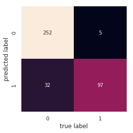

```python
# really promising, need to investigate for leakage

mat = confusion_matrix(y_test, predicted)
sns.heatmap(mat.T, square=True, annot=True, fmt='d', cbar=False)
plt.xlabel('true label')
plt.ylabel('predicted label');
```

```python
#300 is highest prob
X_test.iloc[300]['comments']
```

```
['I miss him',
 'Id protect it the lil jamal can grow up as a bull ',
 'its a shame he is hacking',
 'Close the door',
 'Since all posts got removed by mods on powertrip here discuss ',
 'Whatever that means,also im not a trump supporter and im banned from the donald',
 'go to /r/conspiracy you nuthead',
 'I miss my cat thx for making me cry',
 'i bet u kiss the girls u faggot',
 'Wow 30 bucks so rich,i could literally get tickets yesterday you inbelic',
 'this was a best of 5 he still lost',
 'Ok',
 'guys im memeing',
 'ram ssd amd cpu',
 "I'd suck that dudes dick",
 "Then maybe just maaaaybe don't exploit him? They knew exactly what they were doing and what can happen and they still did it",
 'all tsm is blaming deathtimers now :^ )',
 'I dont like being told to kill myself for supporting a communist (exact words) ty',
 'Check the last post in my history',
 'I might have skipped that part sorry kinda tired',
 'do u support islam?',
 "I fc'd this map and got instantly restricted :(",
 'Texting is straight up annoying or ignored',
 'i was just memeing fam',
 'fuck riot',
 'cancer',
 'didn\'t you elect "duuude its 2016 lmfao free weed" man?',
 'Stoof is hexxer',
 'queue?',
 'http://i.imgur.com/NxHCOFR.png',
 'that feeling when Azer is probably capable of pulling of a Cry Thunder HD HR FC but he is too busy nailing that asian chick ;_;',
 'my dick got hard from this post thanks OP',
 'I just got a new gaming chair bro',
 'Huh those are donations to him,cancer.ca is the fundsraiser',
 'racist',
 'Lawyer up hit the gym and buy pepsi light',
 'Revo uninstaller',
 'Dynamic queue happene',
 'Otakufangirl is a 13 yrs old girl go get her pedos',
 'sure but get out of silver first ',
```

[output cut: 405 more lines]

```
 'follow up is better:\n\nhttps://twitter.com/ppy/status/713296979032297472',
 'sry if i was misinformed but thats what i remember',
 'idk i didnt have a forum for 5 yrs u are prob right',
 'yes i had one with phpbb 6,0 and you could select to not include pws afaik',
 'straight up plain text password\n\nand they wonder why top players got hacked....',
 'did vista give u the acc?',
 'plat 1',
 'lmfao',
 'not ok when this guy keeps being a cunt despite being called out over and over and he just harasses people make up fake bs trying to lie to the sub and overall being cancer',
 'i read your comment and username thinking it was a bait or troll,oh god what have i found in your previous posts',
 'if you used a credit card issue a chargeback',
 'ok',
 'is this osu?',
 'expected results..',
 'I dont think so ...']
```

```python
terms = tfidf.get_feature_names()

sanders2016 = tfidf.transform([X_test.iloc[300]['comments_new']])
# sum tfidf frequency of each term through documents
sums = sanders2016.sum(axis=0)

# connecting term to its sums frequency
data = []
for col, term in enumerate(terms):
    data.append( (term, sums[0,col] ))

ranking = pd.DataFrame(data, columns=['term','rank'])
print(ranking.sort_values('rank', ascending=False)[:10])

#10th ranked word is banned, and the user discusses being banned on other subs
```

```
         term      rank
4558   traded  0.351627
1296     dont  0.201560
3157   paypal  0.193247
2369     just  0.192829
125    amazon  0.185264
908   confirm  0.163483
2530     like  0.161698
2173      ill  0.140945
3171   people  0.124556
317    banned  0.113948
```

[figure not shown]

```python
terms = tfidf.get_feature_names()

lol = tfidf.transform([text])
# sum tfidf frequency of each term through documents
sums = lol.sum(axis=0)

# connecting term to its sums frequency
data = []
for col, term in enumerate(terms):
    data.append( (term, sums[0,col] ))

ranking = pd.DataFrame(data, columns=['term','rank'])
print(ranking.sort_values('rank', ascending=False)[:10])

# of course skype has the highest weight
```

```
               term      rank
4040          skype  0.985586
2980        numbers  0.106210
4748   verification  0.089906
1288        dollars  0.049877
2808        minimum  0.048979
4708            usd  0.030155
2273  international  0.023227
2979         number  0.015747
2918           need  0.015193
711           check  0.014400
```

```python
print(X_test.iloc[287]['comments'])

faithfulgamer = tfidf.transform([X_test.iloc[287]['comments_new']])
# sum tfidf frequency of each term through documents
sums = faithfulgamer.sum(axis=0)

# connecting term to its sums frequency
data = []
for col, term in enumerate(terms):
    data.append( (term, sums[0,col] ))

ranking = pd.DataFrame(data, columns=['term','rank'])
print(ranking.sort_values('rank', ascending=False)[:10])

# id'ing on skype
```

```
['how do i bump this post ?', 'Add me in skype FaithFulGamer', 'add me in skype faithFulGamer']
           term      rank
4040      skype  0.879556
43          add  0.331396
560        bump  0.307854
3317       post  0.147594
0     abilities  0.000000
3337  practical  0.000000
3336        ppr  0.000000
3335        ppl  0.000000
3334     powers  0.000000
3333   powerful  0.000000
```

```python
# look at term document matrix for corpus: nothing about bans in the top terms

terms = tfidf.get_feature_names()

# sum tfidf frequency of each term through documents
sums = tfidfed.sum(axis=0)

# connecting term to its sums frequency
data = []
for col, term in enumerate(terms):
    data.append( (term, sums[0,col] ))

ranking = pd.DataFrame(data, columns=['term','rank'])
print(ranking.sort_values('rank', ascending=False)[:10])
```

```
        term        rank
2369    just  201.860924
2530    like  182.849582
4827   watch  168.782296
837      com  164.941542
2132   https  129.614549
1292     don  116.306533
1878    good  106.419780
4449  thanks  101.911526
4496    time   97.997436
2179   imgur   97.691417
```

[figure not shown]

```python
# mean comment length and negative are important features for the rf/gb classifiers

I = importances(e.eclf, X_train[e.num_cols], y_train)
plot_importances(I)
```

[figure not shown]

```python
df_base.groupby('is_scammer').mean().T
```

| is_scammer | False | True |
| --- | --- | --- |
| link_karma | 3377.491480 | 3114.585082 |
| comment_karma | 4639.712108 | 12564.270396 |
| verified | 0.828700 | 0.662005 |
| mod | 0.090583 | 0.216783 |
| gold | 0.060987 | 0.032634 |
| days_old | 1529.622422 | 1836.496503 |
| total_comments | 529.890583 | 534.979021 |
| positive | 0.548852 | 0.430924 |
| neutral | 0.305084 | 0.370992 |
| negative | 0.146064 | 0.198083 |
| mean_comment_length | 187.423518 | 139.069768 |
| mode_comment_length | 74.506726 | 97.291375 |
| median_comment_length | 101.182511 | 94.504662 |
| duplicate_comments | 21.257399 | 35.622378 |
| avg_grammar | 1.933850 | 2.993266 |
| total_grammar | 925.415247 | 1794.829837 |
| cap_freq_mean | 0.068076 | 0.068844 |

```python
# p-values low, significant

neg_scammer = df_base.negative[df_base.is_scammer == True].values
neg_users = df_base.negative[df_base.is_scammer == False].values
length_scammer = df_base.mean_comment_length[df_base.is_scammer == True].values
length_users = df_base.mean_comment_length[df_base.is_scammer == False].values

from scipy import stats
print(stats.ttest_ind(neg_scammer,neg_users))
print(stats.ttest_ind(length_scammer,length_users))
```

```
Ttest_indResult(statistic=9.066882185130869, pvalue=3.621066314912919e-19)
Ttest_indResult(statistic=-4.426723265437426, pvalue=1.0240079360672573e-05)
```

```
accuracy: 0.9585492227979274
precision: 0.8909090909090909
recall: 0.9607843137254902
auc score: 0.9592653962993649
```

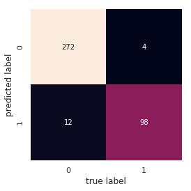

```python
#auc score increased with ensemble, recall and precision are great!

threshold = .50
predicted = final_preds >= threshold
accuracy = accuracy_score(y_test, predicted)
precision = precision_score(y_test, predicted)
recall = recall_score(y_test, predicted)

print("accuracy:", accuracy)
print("precision:", precision)
print("recall:", recall)
print("auc score:", roc_auc_score(y_test,predicted))

mat = confusion_matrix(y_test, predicted)
sns.heatmap(mat.T, square=True, annot=True, fmt='d', cbar=False)
plt.xlabel('true label')
plt.ylabel('predicted label');
```

[figure not shown]

```python
# Import more users from all 60+ subreddits participating in the universal ban list

e2 = ensemble(df_mix)
e2.split()
e2.train_fit()
test_preds = e2.test_predict()
```

```python
#ensemble model
#precision and recall poor, even with threshold at .25 the recall is only 50%

threshold = .25
predicted = test_preds >= threshold
accuracy = accuracy_score(e2.y_test, predicted)
precision = precision_score(e2.y_test, predicted)
recall = recall_score(e2.y_test, predicted)

print("accuracy:", accuracy)
print("precision:", precision)
print("recall:", recall)
print("auc score:", roc_auc_score(e2.y_test,test_preds))
```

```
accuracy: 0.84
precision: 0.4796747967479675
recall: 0.5130434782608696
auc score: 0.8540910647038685
```

[figure not shown]

```python
# ouch a lot of false negatives

mat = confusion_matrix(e2.y_test, predicted)
sns.heatmap(mat.T, square=True, annot=True, fmt='d', cbar=False)
plt.xlabel('true label')
plt.ylabel('predicted label');
```

```python
# Multinomial naive bayes model
# Doesn't even predict any true labels until .20 threshold, can't separate the groups

threshold = .20
predicted = test_preds >= threshold
accuracy = accuracy_score(e2.y_test, predicted)
precision = precision_score(e2.y_test, predicted)
recall = recall_score(e2.y_test, predicted)

print("accuracy:", accuracy)
print("precision:", precision)
print("recall:", recall)
print("auc score:", roc_auc_score(e2.y_test,test_preds))
```

```
accuracy: 0.844
precision: 0.4166666666666667
recall: 0.043478260869565216
auc score: 0.7122629236562821
```

```python
#negative and mean comment length not as important as features anymore

I = importances(e2.eclf, e2.X_train, e2.y_train)
plot_importances(I)
```

[figure not shown]

```python
df_mix.groupby('is_scammer').mean().T
```

| is_scammer | False | True |
| --- | --- | --- |
| link_karma | 4286.909692 | 3114.585082 |
| comment_karma | 5922.149085 | 12564.270396 |
| verified | 0.836902 | 0.662005 |
| mod | 0.185675 | 0.216783 |
| gold | 0.039315 | 0.032634 |
| days_old | 1206.907357 | 1836.496503 |
| total_comments | 581.841962 | 534.979021 |
| positive | 0.474507 | 0.430924 |
| neutral | 0.346045 | 0.370992 |
| negative | 0.179448 | 0.198083 |
| mean_comment_length | 131.345476 | 139.069768 |
| mode_comment_length | 43.673025 | 97.291375 |
| median_comment_length | 80.420786 | 94.504662 |
| duplicate_comments | 45.915142 | 35.622378 |
| avg_grammar | 1.670656 | 2.993266 |
| total_grammar | 1051.750487 | 1794.829837 |
| cap_freq_mean | 0.067438 | 0.068844 |

```python
neg_scammer = df_mix.negative[df_mix.is_scammer == True].values
neg_users = df_mix.negative[df_mix.is_scammer == False].values
length_scammer = df_mix.mean_comment_length[df_mix.is_scammer == True].values
length_users = df_mix.mean_comment_length[df_mix.is_scammer == False].values

from scipy import stats
print(stats.ttest_ind(neg_scammer,neg_users))
print(stats.ttest_ind(length_scammer,length_users))

# mean comment length not significant anymore, negative still significant but not distinct enough
```

```
Ttest_indResult(statistic=3.2520479779977856, pvalue=0.0011584710648988813)
Ttest_indResult(statistic=1.0159228773021844, pvalue=0.30974814696978026)
```

# What happened?

- Adding more users from a variety of subreddits waters down the comments
  - Initial data was only users from watchexchange and then banned users
  - Most likely separating or identifying scammers based off of demographics that were picked up in the comments
  - Negative speech less distinct as you include users from all parts of Reddit
- Possible that I am mislabeling a lot of non-scammers:
  - I'm only labeling unbanned users on those buy/trade/sell subreddits as a non-scammer, but they might be scammers that haven't been caught yet

# Last thoughts

- Use Selenium to scrape more information that PRAW doesn't not provide
  - Frequent subreddits they comment in or post in
  - Date time of the comments history - Remove comments after ban date
- Attempt using other tools such as a neural network to train on comments
  - Seemed to be some merit with naive bayes at first, so it may still be worth investigating with other tools
  - VADER sentiment analyzer was a simple classifier for comments, could be expanded on
- Base parameters for all of the gradient boosted and random forest models, a lot can be done in tuning parameters as well as feature engineering
- Able to build a Flask app, even if the original goal for predicting scammers turns out to futile after more tuning and feature engineering, can easily modify the scripts into a Reddit profile builder
  - Scrape a person's comment history, divide into different sentiments, etc.

# Data Science

## 30%

# Data Engineering

## 50%

# Presentation

## 20%